# ggplot2 Package

Data Visualization

Description functions provided in ggplot2 Package

Yeongeun Jeon  
07-06-2022

- **참고 : R과 통계분석(Tidyverse 활용), 박동련 저**

# **1. 데이터 탐색**

> R에 입력된 데이터 세트를 전처리 과정을 통해 통계분석이 가능한 깔끔한 데이터로 정리하고 나면, 다양한 방법을 통해 데이터의 특성을 관찰하고 이해하는 과정이 필요하다. 이러한 과정을 “데이터 탐색”이라고 하며, 대표적인 데이터 탐색 방법은 요약 통계량과 시각화이다. 특히, 데이터 시각화는 도표를 비롯한 여러 수단을 통해 데이터에 숨겨진 정보를 명확하고 효과적으로 전달한다. 데이터 시각화를 수행하기 위해 R에서 널리 사용되는 Package는 `ggplot2` (Ver. 3.3.5)이다. Package `ggplot2`는 일관된 기초 문법을 가지고 있으며, 함수가 직관적이고 비교적 쉽게 완성도가 높은 그래프를 그릴 수 있다는 것이다. 따라서, 이 장에서는 Package `ggplot2`를 이용하여 데이터 유형에 따른 다양한 시각화 방법에 대해 살펴본다.

## **1-1. 데이터 유형에 따른 시각화 종류**

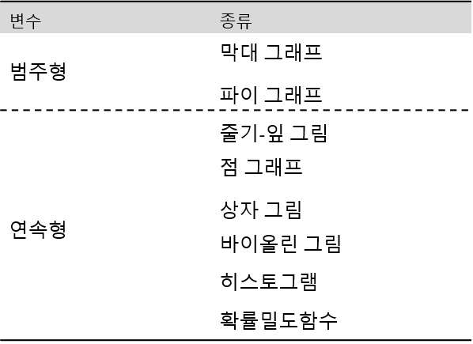

## **1-2. Package ggplot2 설치**

```
# 1. 기본적인 패키지 설치와 로드 방법NA# install.packages("ggplot2")
library(ggplot2)
```

```
# 2. p_load 이용하여 설치와 로드를 한꺼번에 에
# install.packages("pacman")    # For p_load
pacman::p_load("ggplot2")          # pacman::p_load : pacman 패키지의 p_load함수 사용NA
```

`Result!` 함수 `p_load()`는 작성된 패키지가 설치 되어있지 않으면 설치 후 함수 `library()`를 자동적으로 실행한다.

## **1-3. 데이터**

> Package `ggplot2`에 내장되어 있는 데이터 “mpg”를 이용하여 시각화 방법에 대해 설명할 것이다. 데이터 “mpg”는 미국환경 보호국(US Environmental Protection Agency)에서 공개한 데이터로 1999~2008년 사이에 미국에서 출시된 자동차 234종의 연비 관련 정보를 담고 있으며, 변수는 다음과 같다.

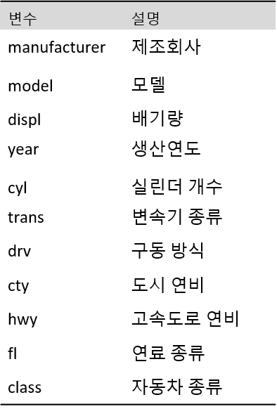

```
pacman::p_load("dplyr")                   # For preprocessing

# 데이터 불러오기
data("mpg")
data <- mpg
str(data)
```

```
tibble [234 x 11] (S3: tbl_df/tbl/data.frame)
 $ manufacturer: chr [1:234] "audi" "audi" "audi" "audi" ...
 $ model       : chr [1:234] "a4" "a4" "a4" "a4" ...
 $ displ       : num [1:234] 1.8 1.8 2 2 2.8 2.8 3.1 1.8 1.8 2 ...
 $ year        : int [1:234] 1999 1999 2008 2008 1999 1999 2008 1999 1999 2008 ...
 $ cyl         : int [1:234] 4 4 4 4 6 6 6 4 4 4 ...
 $ trans       : chr [1:234] "auto(l5)" "manual(m5)" "manual(m6)" "auto(av)" ...
 $ drv         : chr [1:234] "f" "f" "f" "f" ...
 $ cty         : int [1:234] 18 21 20 21 16 18 18 18 16 20 ...
 $ hwy         : int [1:234] 29 29 31 30 26 26 27 26 25 28 ...
 $ fl          : chr [1:234] "p" "p" "p" "p" ...
 $ class       : chr [1:234] "compact" "compact" "compact" "compact" ...
```

```
# For 시각화화
data <- data %>%
  mutate_if(is.character, as.factor)     # 문자형 변수를 범주형 변수로 변환환

str(data)
```

```
tibble [234 x 11] (S3: tbl_df/tbl/data.frame)
 $ manufacturer: Factor w/ 15 levels "audi","chevrolet",..: 1 1 1 1 1 1 1 1 1 1 ...
 $ model       : Factor w/ 38 levels "4runner 4wd",..: 2 2 2 2 2 2 2 3 3 3 ...
 $ displ       : num [1:234] 1.8 1.8 2 2 2.8 2.8 3.1 1.8 1.8 2 ...
 $ year        : int [1:234] 1999 1999 2008 2008 1999 1999 2008 1999 1999 2008 ...
 $ cyl         : int [1:234] 4 4 4 4 6 6 6 4 4 4 ...
 $ trans       : Factor w/ 10 levels "auto(av)","auto(l3)",..: 4 9 10 1 4 9 1 9 4 10 ...
 $ drv         : Factor w/ 3 levels "4","f","r": 2 2 2 2 2 2 2 1 1 1 ...
 $ cty         : int [1:234] 18 21 20 21 16 18 18 18 16 20 ...
 $ hwy         : int [1:234] 29 29 31 30 26 26 27 26 25 28 ...
 $ fl          : Factor w/ 5 levels "c","d","e","p",..: 4 4 4 4 4 4 4 4 4 4 ...
 $ class       : Factor w/ 7 levels "2seater","compact",..: 2 2 2 2 2 2 2 2 2 2 ...
```

# **2. 범주형 데이터 탐색**

> 여러 범주로 이루어진 범주형 데이터는 명목형 데이터와 순서형 데이터로 구분된다.

|  | 설명 | 예시 |
| --- | --- | --- |
| 명목형 데이터 | 범주들 간에 순서척도가 없는 경우 | 거주지, 성별, 혈액형 |
| 순서형 데이터 | 범주들을 순서에 따라 나열할 수 있는 경우 | 학년, 만족도 |

※ 이 절에서는 명목명과 순서형 구분 없이 모두에게 잘 적용되는 그래프들을 살펴볼 것이다.

## **2-1. 일변량 범주형 데이터 탐색**

- 범주형 데이터가 주어지면 가장 먼저 해야 할 작업은 도수분포표 또는 분할표를 작성하는 것이다.
  - 일변량 범주형 데이터에 대한 도수분포표는 함수 `table()`을 이용하여 나타낼 수 있다.
  - 또한, 작성된 도수분포표를 백분율로 나타낼려면 함수 `prop.table(도수분포표)`을 이용한다.

```
# 변수 class의 도수분포표
count <- table(data$class)
count
```

```
   2seater    compact    midsize    minivan     pickup subcompact
         5         47         41         11         33         35
       suv
        62
```

```
# 백분율
prop.table(count)
```

```
   2seater    compact    midsize    minivan     pickup subcompact
0.02136752 0.20085470 0.17521368 0.04700855 0.14102564 0.14957265
       suv
0.26495726
```

### **2-1-1. 막대 그래프**

- 범주형 데이터에 대해 가장 흔하게 볼 수 있는 그래프로서, 각 범주의 도수를 막대의 높이로 나타내는 그래프이다.
- 막대 그래프를 작성하기 위해서는 함수 `geom_bar()`를 사용해야 한다.

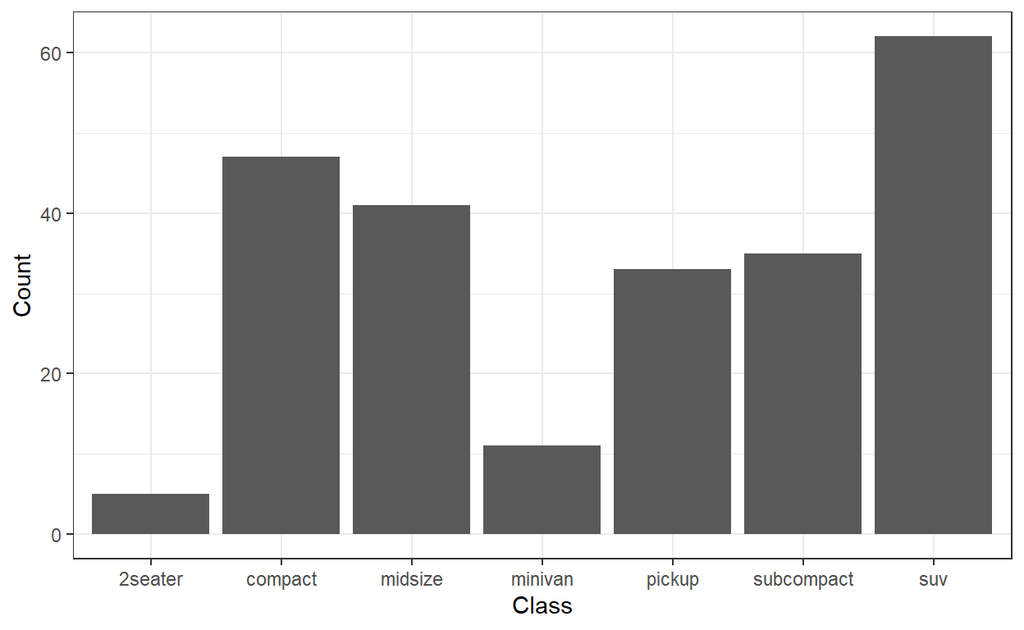

[output not shown]

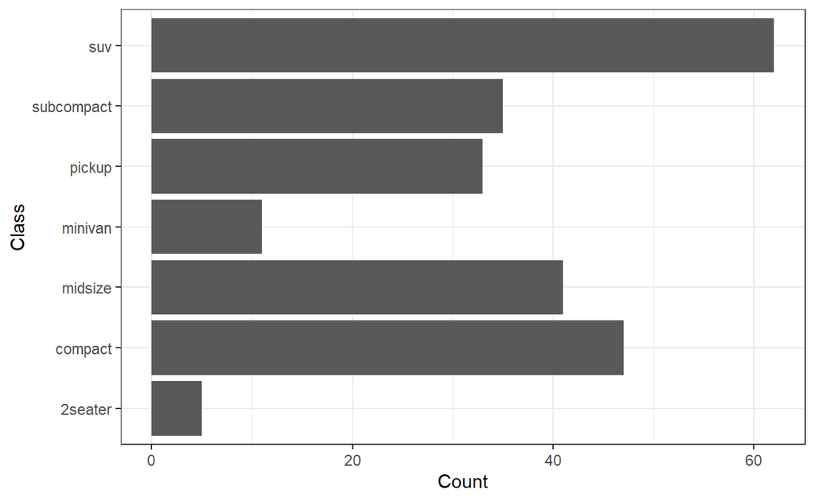

```
p1 + coord_flip()                        # 가로 형태의 막대 그래프
```

`Caution!` 가로 형태의 막대 그래프를 작성하기 위해서는 함수 `coord_flip()`를 추가해야 한다.

#### **2-1-1-1. 막대 그래프의 색깔 변경**

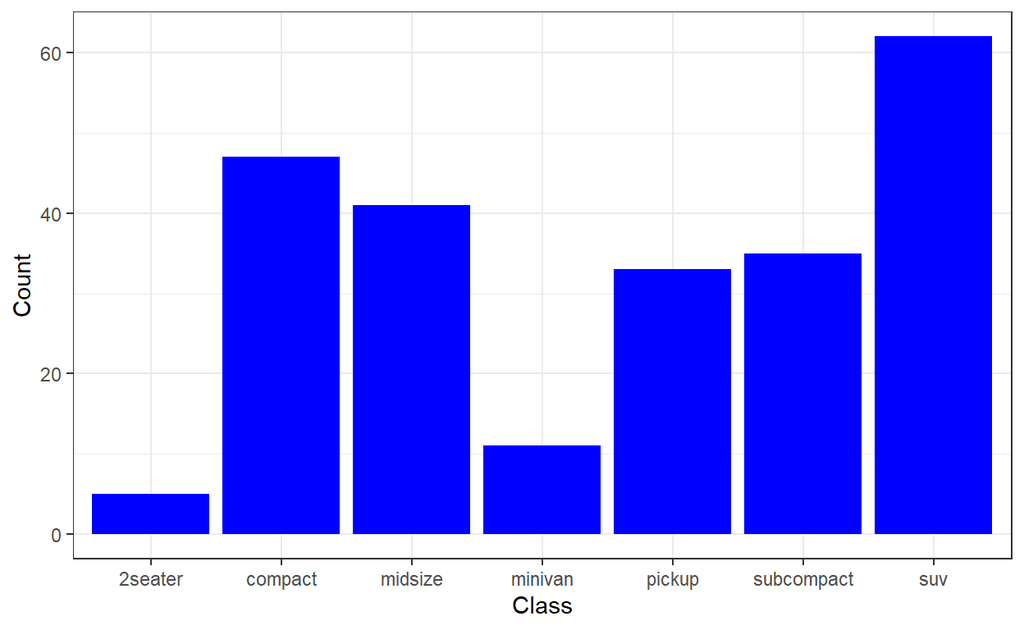

[output not shown]

`Caution!` 막대 그래프의 색깔 변경은 옵션 `fill = 색깔`를 지정하면 된다.

#### **2-1-1-2. 각 범주의 빈도로 주어진 데이터에 대한 막대 그래프**

```
counts <- table(data$class)
counts
```

```
   2seater    compact    midsize    minivan     pickup subcompact
         5         47         41         11         33         35
       suv
        62
```

```
df_counts <- data.frame(counts)
df_counts
```

```
        Var1 Freq
1    2seater    5
2    compact   47
3    midsize   41
4    minivan   11
5     pickup   33
6 subcompact   35
7        suv   62
```

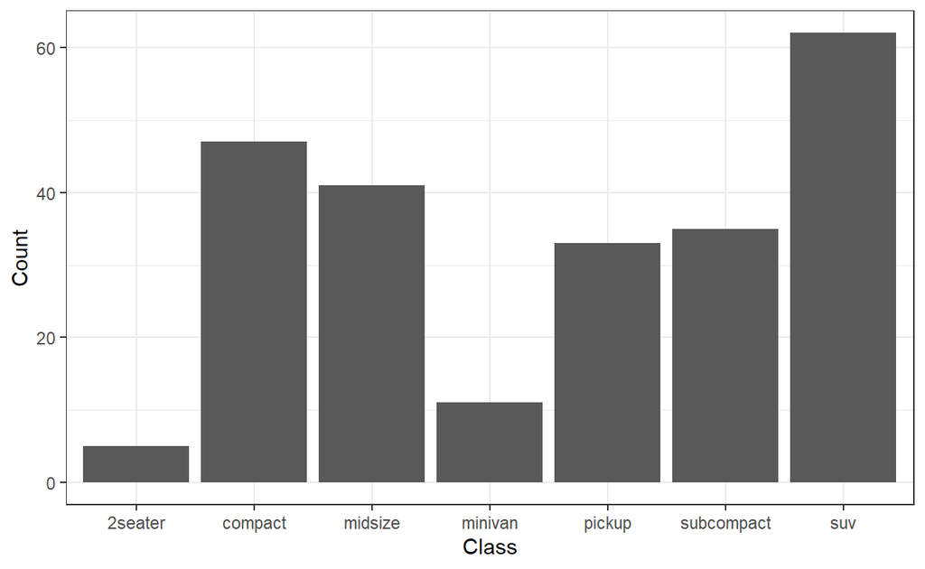

[output not shown]

`Caution!` 데이터가 각 범주의 빈도로 주어진 경우, 막대 그래프를 작성하기 위해서는 함수 `geom_bar()` 에 옵션 `stat = "identity"`을 추가하거나 함수 `geom_col()`을 사용한다.

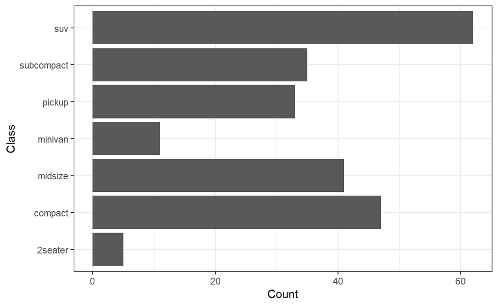

```
p2  + coord_flip()                                    # 가로 형태의 막대 그래프
```

### **2-1-2. 파이 그래프**

- 파이 그래프는 각 범주의 상대도수에 비례한 면적으로 원을 나누어 나타내는 그래프이다.
- 파이 그래프를 작성하기 위해서는 함수 `ggplot()`에서 옵션 `fill = 범주가 입력된 열 이름`를 추가한 후 함수 `coord_polar(theta = "y")`를 사용한다.

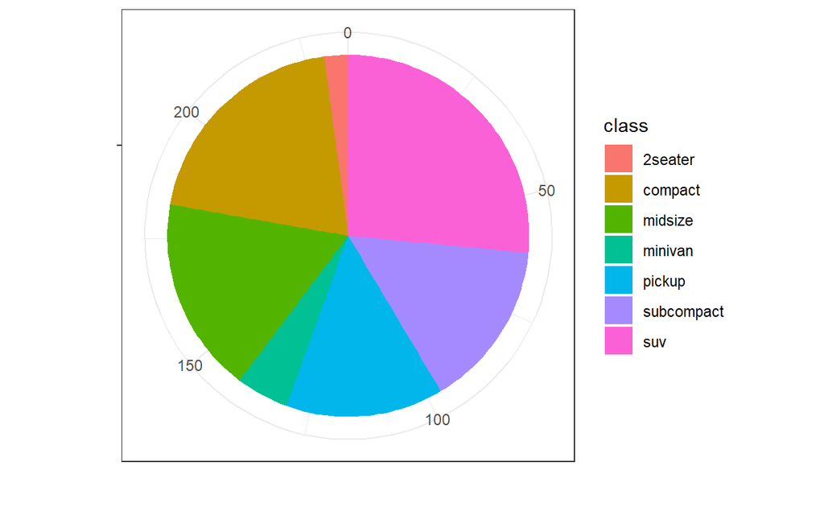

[output not shown]

#### **2-1-2-1. 라벨이 붙여진 파이 그래프**

```
df_prop <- df_counts %>%
  mutate(prob = Freq/sum(Freq))          # 백분율 계산한 변수 추가

df_prop
```

```
        Var1 Freq       prob
1    2seater    5 0.02136752
2    compact   47 0.20085470
3    midsize   41 0.17521368
4    minivan   11 0.04700855
5     pickup   33 0.14102564
6 subcompact   35 0.14957265
7        suv   62 0.26495726
```

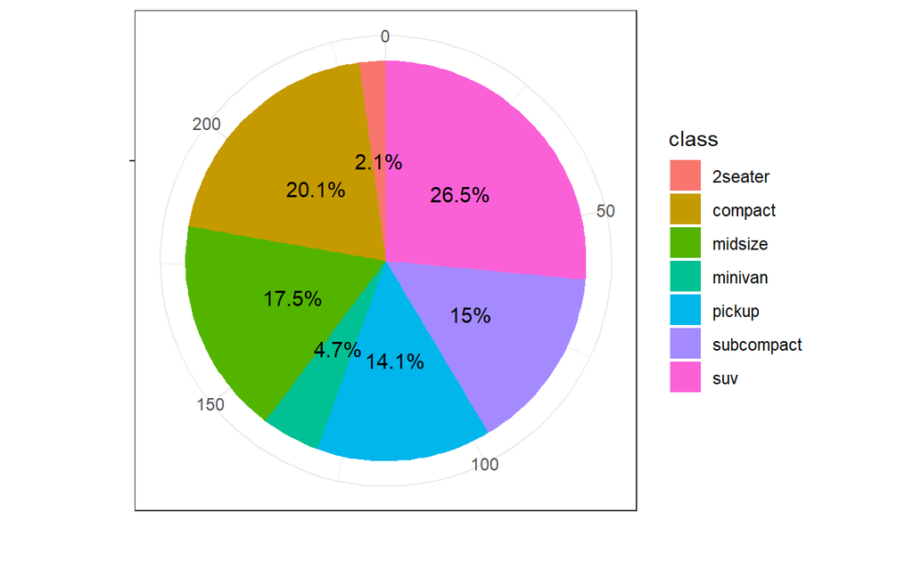

[output not shown]

`Caution!` 그래프에 라벨을 추가하기 위해서는 함수 `geom_text()`를 사용할 수 있다. 함수 `geom_text()`의 옵션 `label`에는 라벨에 넣으려면 내용, 옵션 `position`에는 라벨의 위치를 지정한다.

#### **2-1-2-2. 도넛 그래프**

```
pacman::p_load("ggiraphExtra")

counts <- table(data$class)
counts
```

```
   2seater    compact    midsize    minivan     pickup subcompact
         5         47         41         11         33         35
       suv
        62
```

```
df_counts <- data.frame(counts)
df_counts
```

```
        Var1 Freq
1    2seater    5
2    compact   47
3    midsize   41
4    minivan   11
5     pickup   33
6 subcompact   35
7        suv   62
```

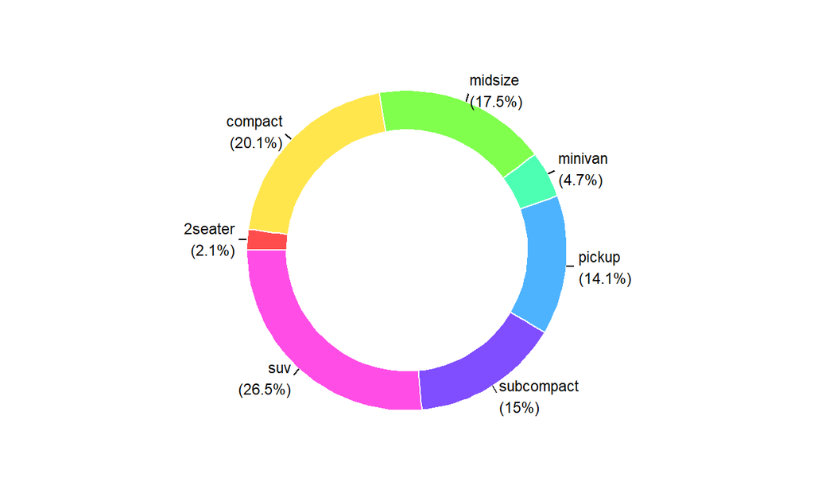

```
ggDonut(df_counts, aes(donuts = Var1, count = Freq))
```

`Caution!` 도넛 그래프를 작성하기 위해서는 Package `ggiraphExtra`에 내장된 함수 `ggDonut`를 사용할 수 있다.

#### **2-1-2-3. 3D 파이 그래프**

```
# 3D 파이 그래프NApacman::p_load("plotrix")               # For pie 3D

counts <- table(data$class)
counts
```

```
   2seater    compact    midsize    minivan     pickup subcompact
         5         47         41         11         33         35
       suv
        62
```

```
# 백분율
prop <- round(prop.table(counts)*100, 1)
prop
```

```
   2seater    compact    midsize    minivan     pickup subcompact
       2.1       20.1       17.5        4.7       14.1       15.0
       suv
      26.5
```

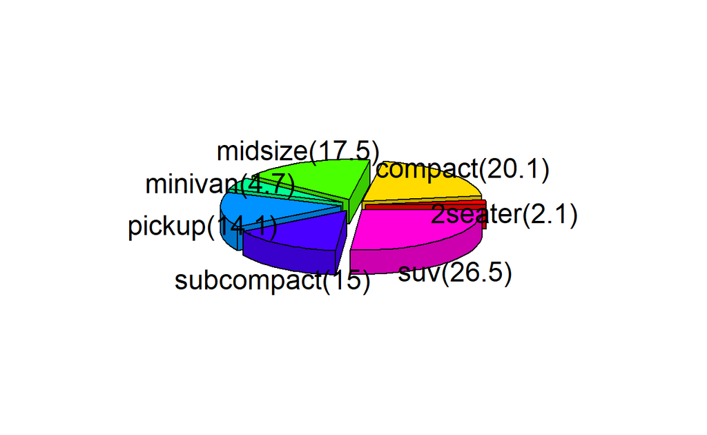

```
pie3D(counts,
      labels =  paste0(names(counts), "(", prop, ")"),
      explode = 0.1)                    # 파이 그래프의 쪼개진 넓이NA
```

`Caution!` 3D 파이 그래프를 작성하기 위해서는 Package `plotrix`에 내장된 함수 `pie3D`를 사용할 수 있다.

## **2-2. 이변량 범주형 데이터 탐색**

- 일변량 범주형 데이터와 마찬가지로 이변량 범주형 데이터에 대한 도수분포표 또는 분할표는 함수 `table()`을 이용하여 나타낼 수 있다.
  - 또한, 작성된 도수분포표 또는 분할표를 백분율로 나타낼려면 함수 `prop.table(도수분포표 또는 분할표)`을 이용한다.

[output not shown]

```
              c  d  e  p  r
  2seater     0  0  0  5  0
  compact     0  1  0 21 25
  midsize     0  0  0 15 26
  minivan     0  0  1  0 10
  pickup      0  0  3  0 30
  subcompact  1  2  0  3 29
  suv         0  2  4  8 48
```

```
table_with <- with(data, table(class, fl))
table_with
```

```
            fl
class         c  d  e  p  r
  2seater     0  0  0  5  0
  compact     0  1  0 21 25
  midsize     0  0  0 15 26
  minivan     0  0  1  0 10
  pickup      0  0  3  0 30
  subcompact  1  2  0  3 29
  suv         0  2  4  8 48
```

`Caution!` 함수 `with()`와 함께 함수 `table()`을 사용하면 변수 이름도 함께 출력된다.

```
# 백분율
prop.table(table)
```

```
                       c           d           e           p
  2seater    0.000000000 0.000000000 0.000000000 0.021367521
  compact    0.000000000 0.004273504 0.000000000 0.089743590
  midsize    0.000000000 0.000000000 0.000000000 0.064102564
  minivan    0.000000000 0.000000000 0.004273504 0.000000000
  pickup     0.000000000 0.000000000 0.012820513 0.000000000
  subcompact 0.004273504 0.008547009 0.000000000 0.012820513
  suv        0.000000000 0.008547009 0.017094017 0.034188034

                       r
  2seater    0.000000000
  compact    0.106837607
  midsize    0.111111111
  minivan    0.042735043
  pickup     0.128205128
  subcompact 0.123931624
  suv        0.205128205
```

```
prop.table(table_with)
```

```
            fl
class                  c           d           e           p
  2seater    0.000000000 0.000000000 0.000000000 0.021367521
  compact    0.000000000 0.004273504 0.000000000 0.089743590
  midsize    0.000000000 0.000000000 0.000000000 0.064102564
  minivan    0.000000000 0.000000000 0.004273504 0.000000000
  pickup     0.000000000 0.000000000 0.012820513 0.000000000
  subcompact 0.004273504 0.008547009 0.000000000 0.012820513
  suv        0.000000000 0.008547009 0.017094017 0.034188034
            fl
class                  r
  2seater    0.000000000
  compact    0.106837607
  midsize    0.111111111
  minivan    0.042735043
  pickup     0.128205128
  subcompact 0.123931624
  suv        0.205128205
```

### **2-2-1. 막대 그래프**

- 이변량 범주형 데이터를 대상으로 그래프를 작성하는 주된 목적은 두 범주형 변수의 관계를 탐색하는 것이다.
- 많이 사용되는 그래프는 막대 그래프이며, 이변량의 경우 쌓아 올린 형태의 막대 그래프와 옆으로 붙여 놓은 형태의 막대 그래프가 사용된다.
  - 일변량 범주형 데이터와 마찬가지로 막대 그래프를 작성하기 위해서는 함수 `geom_bar()`를 사용하면 된다.

#### **2-2-1-1. 쌓아 올린 막대 그래프**

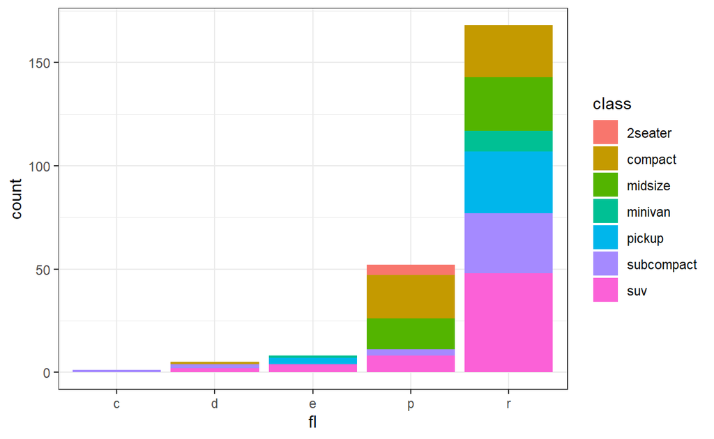

```
ggplot(data, aes(x = fl, fill = class)) +
  geom_bar() +
  theme_bw()
```

`Result!` 변수 “fl”의 빈도와 변수 “fl”내에서 변수 “class”의 빈도를 함께 나타낸다.

#### **2-2-1-2. 옆으로 붙여 놓은 막대 그래프**

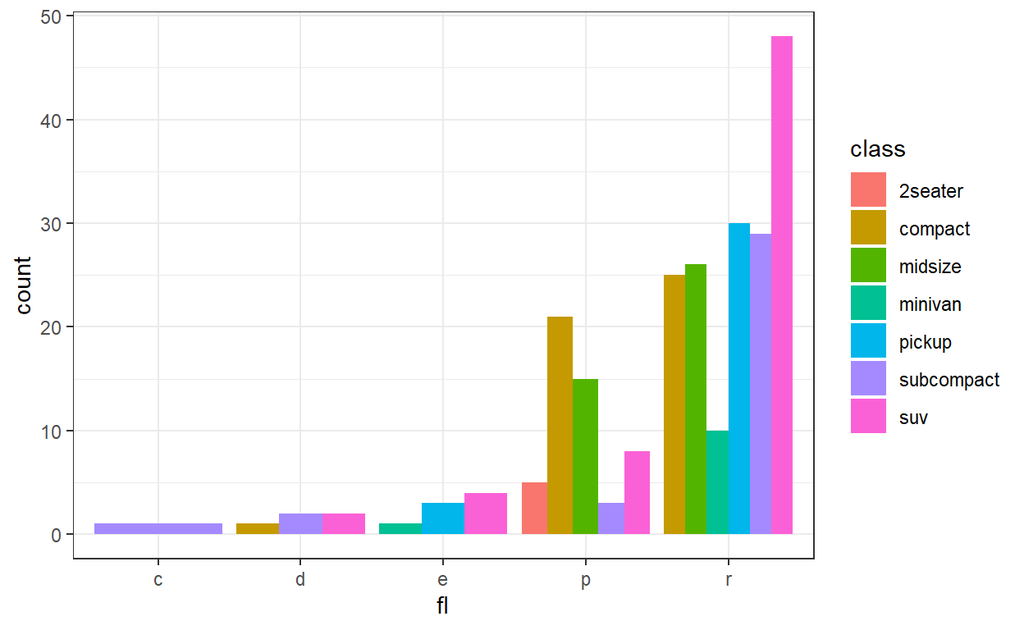

```
ggplot(data, aes(x = fl, fill = class)) +
  geom_bar(position = "dodge") +
  theme_bw()
```

`Caution!` 옆으로 붙여 놓은 막대 그래프를 작성하기 위해서는 함수 `geom_bar()`의 옵션 `position = "dodge"`을 지정해야 한다.  
`Result!` 변수 “fl”내에서 변수 “class”의 빈도를 나타낸다.

#### **2-2-1-3. 라벨이 붙여진 막대 그래프**

```
table <- table(data$class, data$fl)
table
```

```
              c  d  e  p  r
  2seater     0  0  0  5  0
  compact     0  1  0 21 25
  midsize     0  0  0 15 26
  minivan     0  0  1  0 10
  pickup      0  0  3  0 30
  subcompact  1  2  0  3 29
  suv         0  2  4  8 48
```

```
df_table <- data.frame(table)
df_table
```

```
         Var1 Var2 Freq
1     2seater    c    0
2     compact    c    0
3     midsize    c    0
4     minivan    c    0
5      pickup    c    0
6  subcompact    c    1
7         suv    c    0
8     2seater    d    0
9     compact    d    1
10    midsize    d    0
11    minivan    d    0
12     pickup    d    0
13 subcompact    d    2
14        suv    d    2
```

[output cut: 21 more lines]

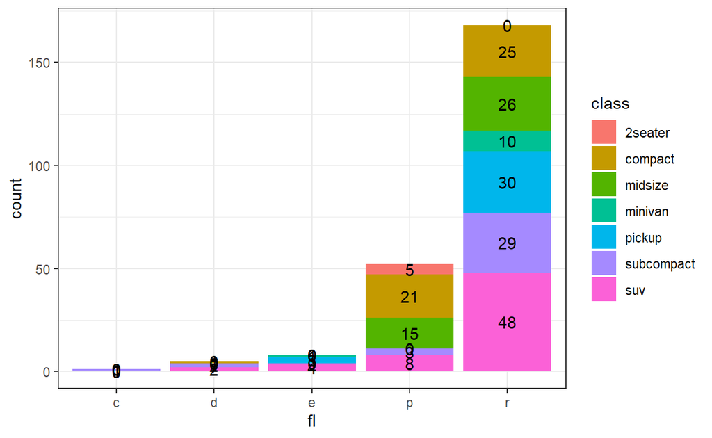

[output not shown]

`Caution!` 그래프에 라벨을 추가하기 위해서는 함수 `geom_text()`를 사용할 수 있다. 함수 `geom_text()`의 옵션 `label`에는 라벨에 넣으려면 내용, 옵션 `position`에는 라벨의 위치를 지정한다.

#### **2-2-1-4. 상대 비율에 대한 막대 그래프**

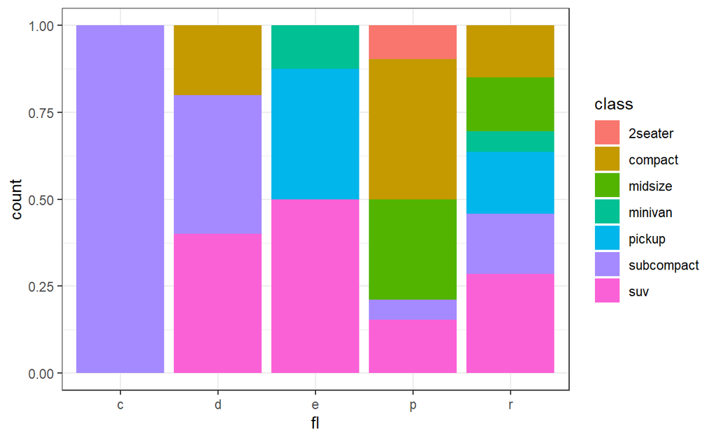

```
ggplot(data, aes(x = fl, fill = class)) +
  geom_bar(position = "fill") +
  theme_bw()
```

`Caution!` 함수 `geom_bar()`의 옵션 `position = "fill"`을 지정하면, 변수 “fl” 내에서 변수 “class”의 상대적인 비율을 나타낼 수 있으며 막대의 높이는 “1”이 된다.

#### **2-2-1-5. 각 범주에 대한 막대 그래프**

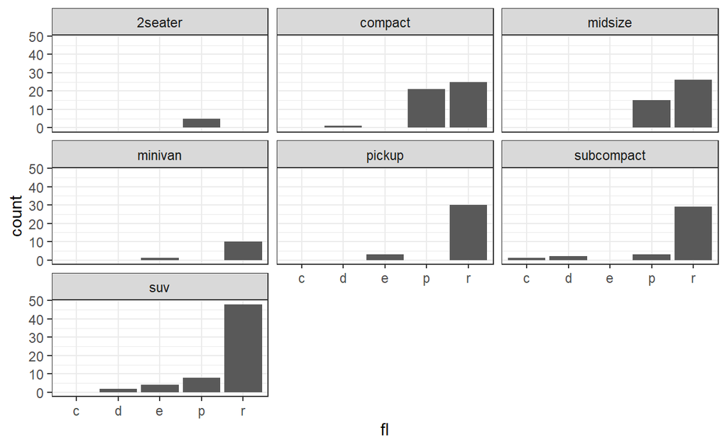

[output not shown]

`Caution!` 함수 `facet_wrap(~변수)`를 사용하면, 지정한 변수의 범주별로 분할하여 그래프를 나타낸다. 이 함수는 범주별 데이터의 분포를 비교하는 데 유용하다.

### **2-2-2. 파이 그래프**

- 이변량 데이터에 대해 파이 그래프를 작성하기 위해 Package `webr`에 내장된 함수 `PieDonut()`를 사용할 수 있다.
  - 함수 `PieDonut()`는 파이 그래프와 도넛 그래프를 합친 그래프를 생성하는 데 쌓아 올린 막대 그래프를 원 그래프로 나타냈다고 생각하면 된다.

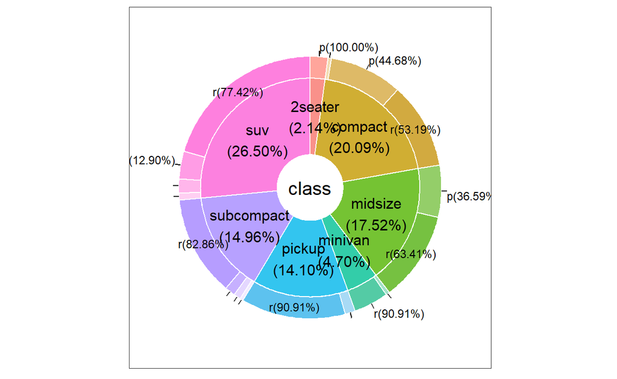

```
pacman::p_load("webr")

PieDonut(data, aes(class, fl))
```

# **3. 연속형 데이터 탐색**

> 연속형 데이터란 측정된 데이터가 연속된 구간의 수치값을 가지는 것을 의미한다. 예를 들어, 수명 시간, 키, 몸무게 등이 있다.

## **3-1. 일변량 연속형 데이터 탐색**

- 일변량 연속형 데이터에 대해서 가장 관심을 가지고 있는 정보는 `데이터의 분포 형태`이다.

### **3-1-1. 줄기-잎 그림**

- 줄기-잎 그림은 비교적 소규모 자료의 분포를 나타내는 데 적합한 그래프이다.
- 데이터를 “줄기”와 “잎”으로 구분하고 “줄기”를 수직으로 세운 후에 해당되는 “줄기”에 “잎”들을 크기 순서로 붙여 나타내는 그림이다.
- 줄기-잎 그림은 함수 `stem()`으로 작성할 수 있다.

```
stem(data$displ)
```

```
  The decimal point is at the |

  1 | 6666688888888888888999
  2 | 0000000000000000000002222224444444444444
  2 | 55555555555555555555777777778888888888
  3 | 000000001111113333333334444
  3 | 555556677788888888999
  4 | 00000000000000022224
  4 | 6666666666677777777777777777
  5 | 002222233333344444444
  5 | 67777777799
  6 | 0122
  6 | 5
  7 | 0
```

### **3-1-2. 점 그래프**

- 점 그래프도 줄기-잎 그림처럼 소규모 데이터의 분포를 표현할 때 유용하게 사용할 수 있는 그래프이다.
- 점 그래프는 함수 `geom_dotplot()`으로 작성할 수 있다.

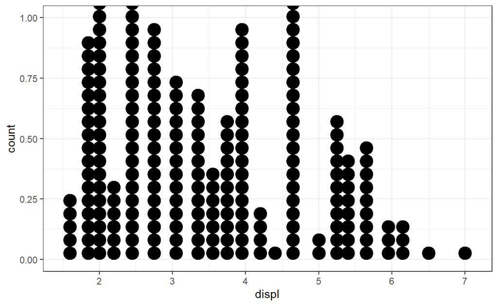

```
ggplot(data, aes(x = displ)) +
  geom_dotplot() +
  theme_bw()
```

### **3-1-3. 상자 그림**

- 상자 그림은 사분위수인 0.25분위수(Q1), 0.5분위수(Q2, 중앙값), 0.75분위수(Q3)를 이용하여 작성하는 단순한 형태의 그래프이다.
- 그래프를 통해 분포의 중심, 퍼짐 정도, 치우침 정도, 꼬리의 길이 등이 상당히 명확하게 나타난다.
- 상자 그림을 작성하기 위해서는 함수 `geom_boxplot()`을 사용해야 한다.
  - 사분위수 범위(Q3-Q1)의 1.5배가 넘는 관찰값들은 따로 점으로 표시된다.

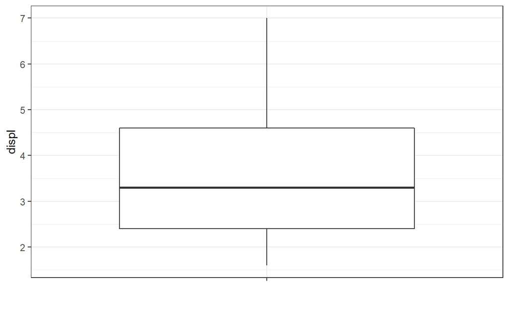

```
bx <- ggplot(data, aes(x = "", y = displ)) +
  geom_boxplot() +
  labs(x = "") +                                                 # x축 label 변경
  theme_bw()
bx
```

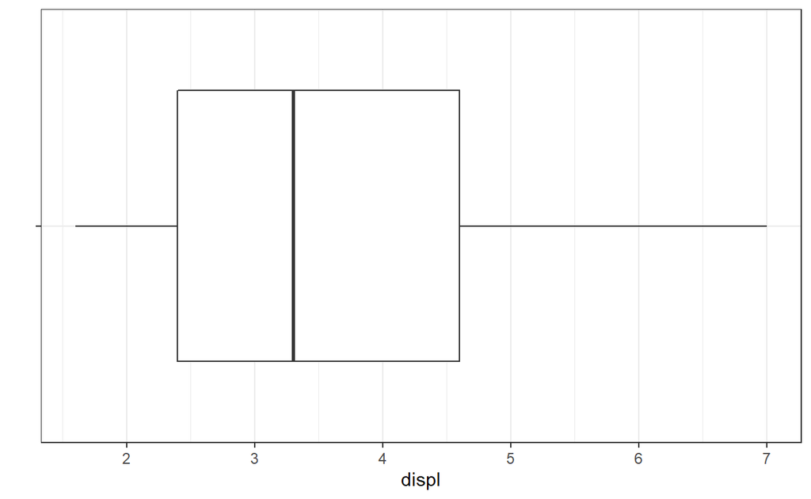

```
bx + coord_flip()                                                # 가로 형태의 상자 그림NA
```

`Caution!` 가로 형태의 상자 그림을 작성하기 위해서는 함수 `coord_flip()`를 추가해야 한다.

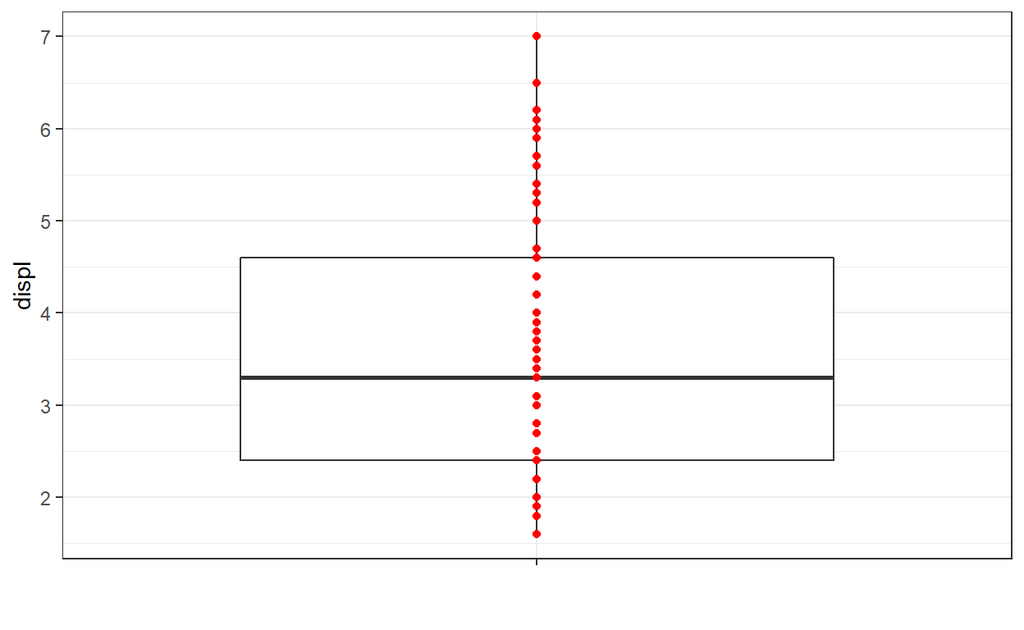

```
bx + geom_point(color = "red")
```

`Caution!` 상자 그림에 데이터의 위치를 점으로 함께 나타내기 위해 함수 `geom_point()`를 사용할 수 있다.

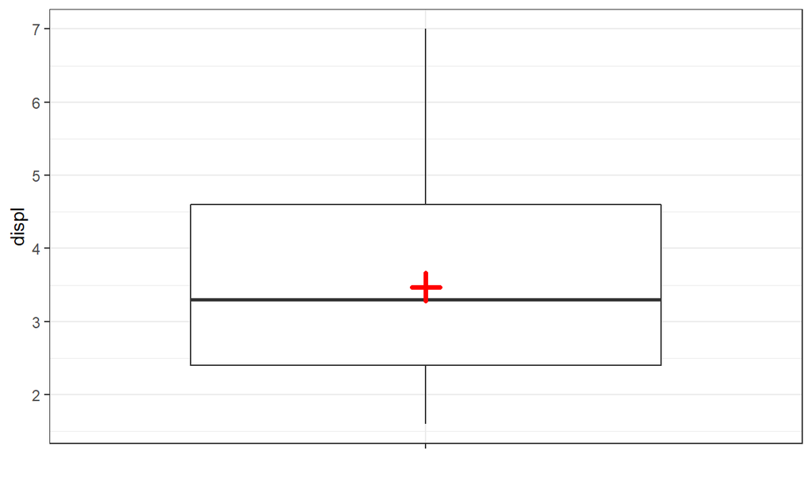

[output not shown]

`Caution!` 상자 그림에 평균값의 위치를 나타내기 위해 함수 `stat_summary()`를 사용할 수 있다.

### **3-1-4. 바이올린 그림**

- 바이올린 그림은 상자 그림에 부가적인 정보를 추가한 변형된 형태의 상자 그림이다.
  - 이 그래프는 상자 그림과 확률밀도함수 그래프의 조합이라고 할 수 있다.
- 바이올린 그림을 작성하기 위해서는 함수 `geom_violin()`을 사용해야 한다.

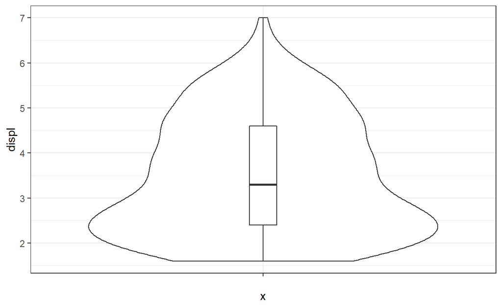

```
ggplot(data, aes(x = "", y = displ)) +
  geom_violin() +
  geom_boxplot(width = 0.07) +                                    # 상자 그림도 함께 나타내기타내기
  theme_bw()
```

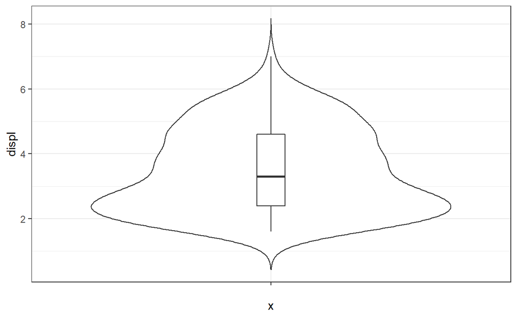

```
ggplot(data, aes(x = "", y = displ)) +
  geom_violin(trim = FALSE) +
  geom_boxplot(width = 0.07) +                                    # 상자 그림도 함께 나타내기타내기
  theme_bw()
```

`Caution!` 함수 `geom_violin()`에 옵션 `trim = FALSE`를 지정하면 그래프의 양 끝부분을 다듬지 않는다.

### **3-1-5. 히스토그램**

- 히스토그램은 연속형 자료의 분포를 시각화하는 데 가장 많이 사용되는 그래프이다.
- 히스토그램을 작성하기 위해서는 함수 `geom_histogram()`을 사용해야 한다.

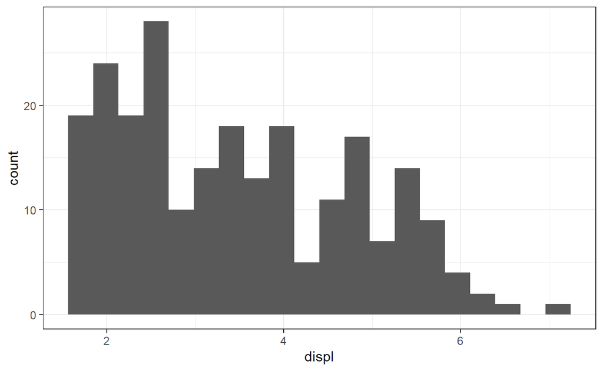

```
ggplot(data, aes(x = displ)) +
  geom_histogram(bins = 20) +
  theme_bw()
```

`Caution!` 함수 `geom_histogram()`에 옵션 `bins`를 통해 구간의 개수를 지정할 수 있다.

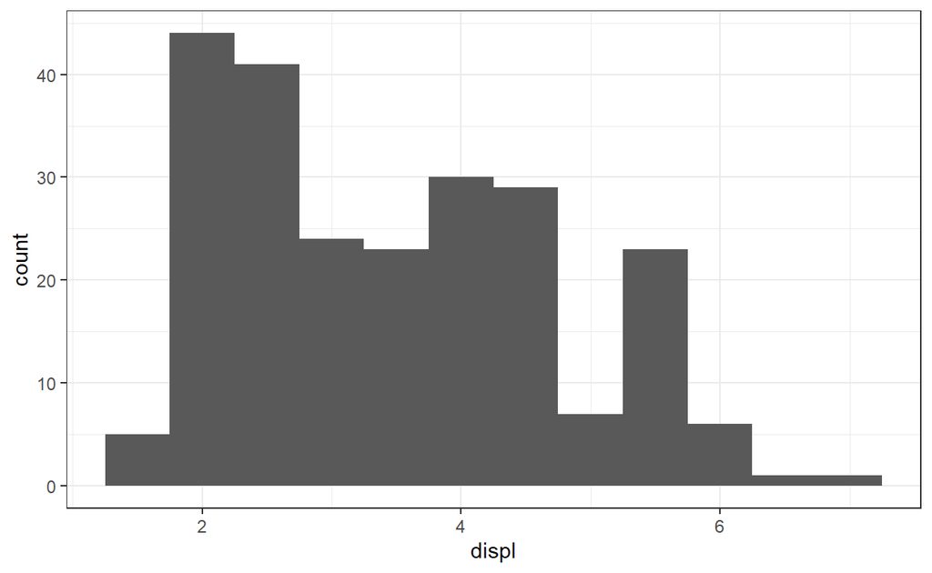

```
ggplot(data, aes(x = displ)) +
  geom_histogram(binwidth = 0.5) +
  theme_bw()
```

`Caution!` 함수 `geom_histogram()`에 옵션 `binwidth`를 통해 구간의 폭을 지정할 수 있다.

### **3-1-6. 확률밀도함수**

- 데이터의 확률밀도함수 그래프는 대규모의 데이터에도 쉽게 적용되며 분포의 세밀한 특징도 잘 나타낸다는 장점이 있다.
- 확률밀도함수 그래프를 작성하기 위해서는 함수 `geom_density()`를 사용해야 한다.

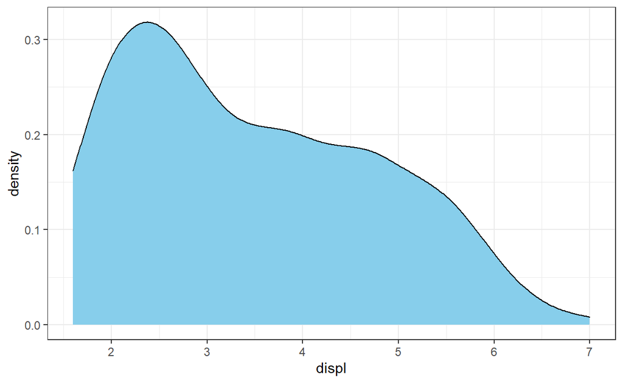

```
ggplot(data, aes(x = displ)) +
  geom_density(fill = "skyblue") +
  theme_bw()
```

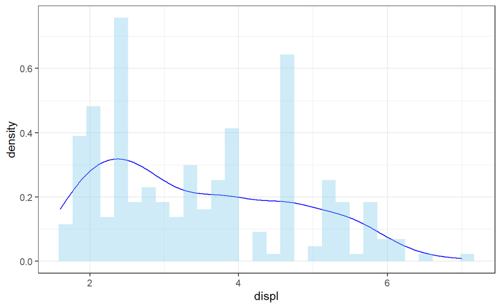

```
ggplot(data, aes(x = displ, y = stat(density))) +
  geom_density(color = "blue") +
  geom_histogram(fill = "skyblue", alpha = 0.4) +
  theme_bw()
```

`Caution!` 히스토그램과 확률밀도함수 그래프를 같이 나타내기 위해서는 함수 `ggplot()`에 `y = stat(density)`를 지정해줘야 한다.

## **3-2. 이변량 연속형 데이터 탐색**

- 연속형 변수가 두 개 혹은 그 이상 주어질 때 주된 관심은 변수들의 분포 비교와 변수 사이의 관계를 탐색하는 것이다.

### **3-2-1. 산점도**

- 두 연속형 변수의 관계를 탐색할 때 가장 많이 사용되는 그래프는 산점도이다.
- 산점도를 확인해 보면 두 변수의 관계를 시각적으로 파악할 수 있는데, 산점도에 두 변수의 회귀직선이나 비모수 회귀곡선 등을 추가하면 관계 파악에 더 도움이 된다.
- 산점도는 함수 `geom_point()`를 통해 작성할 수 있다.

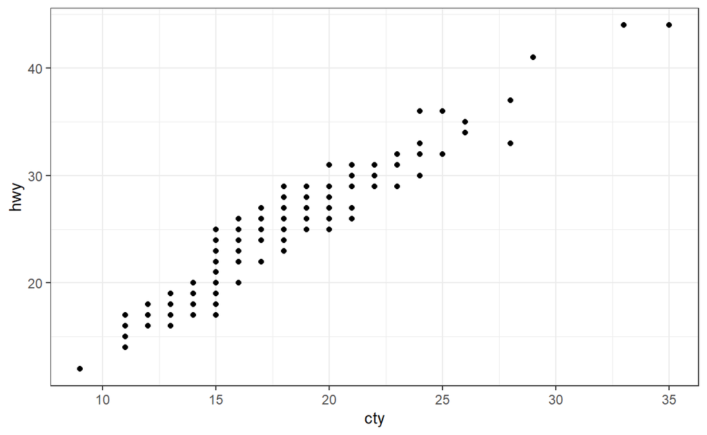

```
p1 <- ggplot(data, aes(x = cty, y = hwy)) +
  geom_point() +
  theme_bw()
p1
```

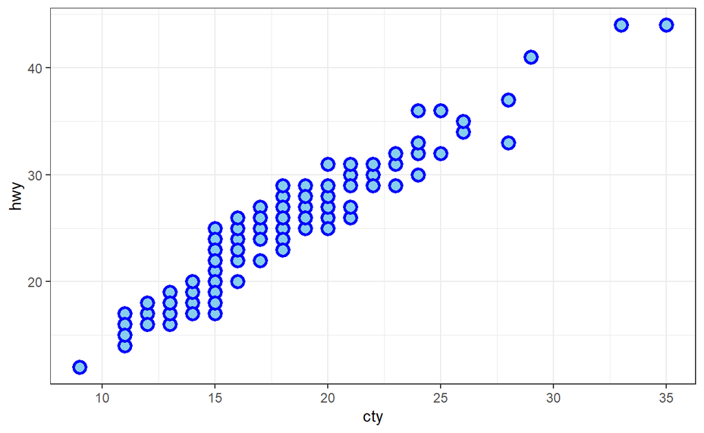

```
ggplot(data, aes(x = cty, y = hwy)) +
  geom_point(shape = 21,                                         # 점 모양
             color = "blue",                                     # 점 외곽선 색깔깔
             fill = "skyblue",                                   # 점 안 색깔
             stroke = 1.5,                                       # 점 외곽선 두께두께
             size = 3) +                                         # 점 크기
  theme_bw()
```

`Caution!` 함수 `geom_point()`의 다양한 옵션 지정을 통해 산점도에 변화를 줄 수 있다. 자세한 옵션은 [여기](https://www.rdocumentation.org/packages/ggplot2/versions/3.3.6/topics/geom_point)를 참고한다.